# Capstone Milestone Report

John Mitchell

December 8, 2015

This report is a accounting of exploratory data analysis on three large corpus files containing blogs, news, and tweets from US English sources.The goal of this analysis is to get a sense of the complexity, size, and scope of the corpora by breaking them into words and phrases (n-grams) and graphing some simple relationships.

First, the files are downloaded and loaded into a working directory. The working directory is named and the files are referenced for easier retrieval

These files are then read into our environment so that they can be analyzed. (using a connection and the readLines function)

We will then create a document frequency matrix with each file (using the Quanteda package). This converts the words to lower case, removes numbers and punctuation, and calculates the frequencies of each word (or unigram).

With these initial files, we can then get a sense of the size and shape of the files. The Dim attribute of each DFM will give us the number of sentences and features(words) for each corpus.

```r
# Blog Dimensions (documents and unigrams)
usb@Dim
```

```
## [1] 899288 387402
```

```r
# News Dimensions (documents and unigrams)
usn@Dim
```

```
## [1] 1010242  336677
```

```r
# Twitter Dimensions (documents and unigrams)
ust@Dim
```

```
## [1] 2360148  396632
```

A histogram of each would show that the word distribution is overwhelmed by the few most common words like “the”, “of”, “is”, etc. These common words are called stop words but they have been left in our document frequency matrix because they will be invaluable in making word predictions.

A variable distribution plot shows the frequency of words by their rank. This helps to show graphically just how dominant the most common words are within each corpus. There is a long tail of hundreds of thousands of words that appear just a small handful of times, even though here we have just graphed the top 1000 features.

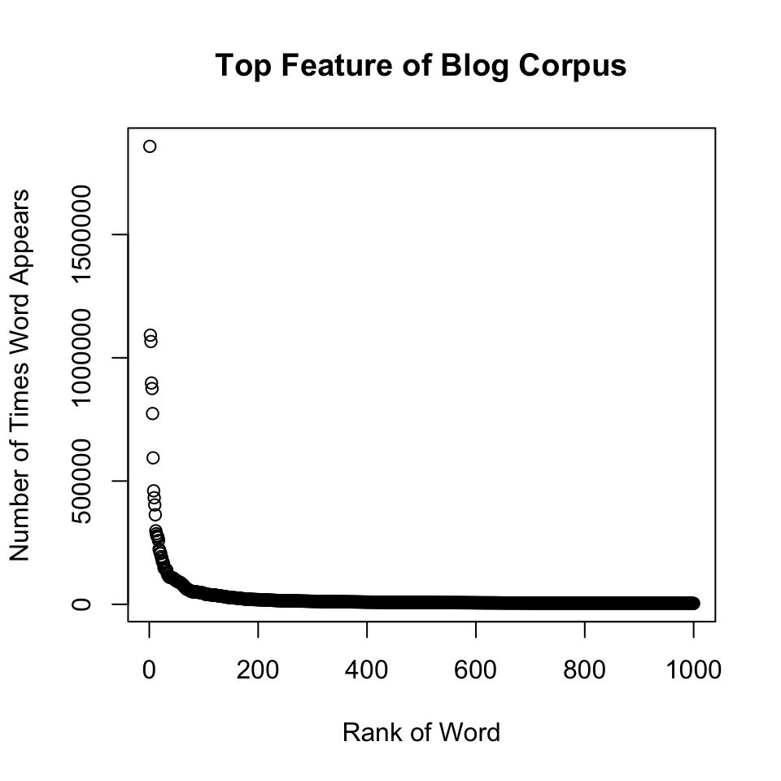

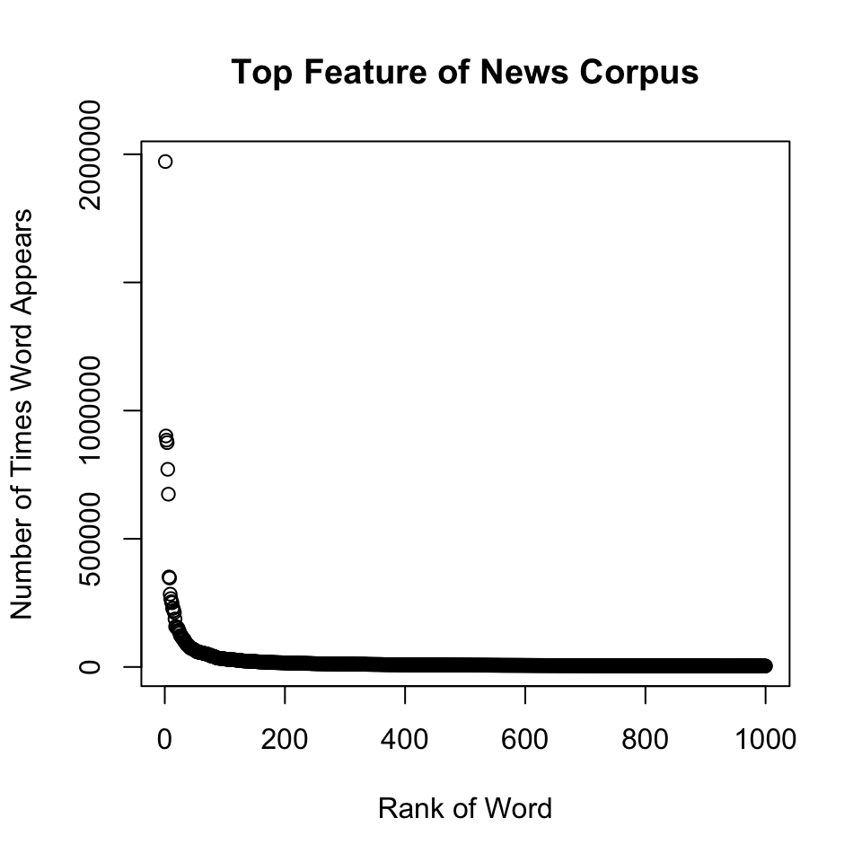

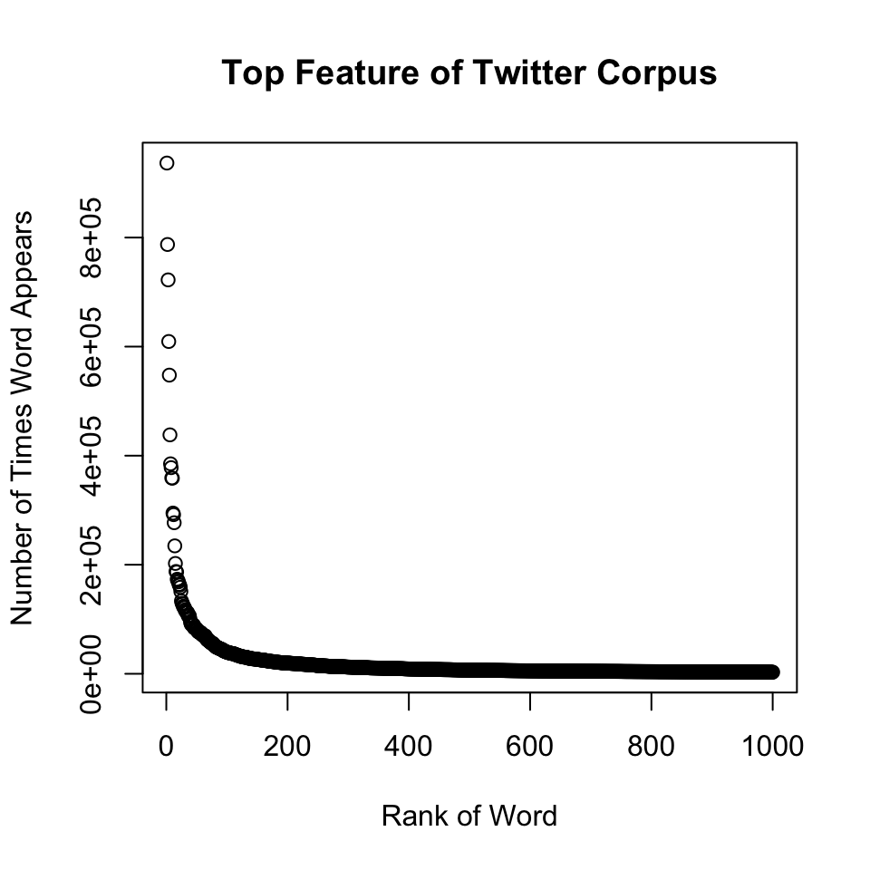

Although each corpus contains hundreds of thousands of words, 90% of the English language can be covered by just 2800 words (via the New General Service List). Moving forward, one of the biggest challenges will be trading off between accuracy and file size. The table below shows the number of unigrams, bigrams, and trigrams for each corpus. Any prediction model for the final project will need to appropriately resize these files to be able to work in a reasonable amount of time.

```
##         Documents Unigrams Bigrams Trigrams
## Blogs      899288   387402 6387153 19046315
## News      1010242   336677 6328674 17925868
## Twitter   2360148   396632 5213533 13541151
```

## Archive

Set the working directory and name the files

```r
setwd("~/Desktop/Coursera/Capstone")
library(quanteda)

blogs <- "./en_US/en_US.blogs.txt"
news <- "./en_US/en_US.news.txt"
twitter <- "./en_US/en_US.twitter.txt"
```

```r
con <- file(blogs, "r")
USblogs <- readLines(con)
close(con)

con <- file(news, "r")
USnews <- readLines(con)
close(con)

con <- file(twitter, "r")
UStwitter <- readLines(con)
close(con)
```

```r
usb <- dfm(USblogs, verbose = TRUE, toLower = TRUE, removeNumbers = TRUE, removeTwitter = TRUE, ngrams = 1)
usn <- dfm(USnews, verbose = TRUE, toLower = TRUE, removeNumbers = TRUE, removeTwitter = TRUE, ngrams = 1)
ust <- dfm(UStwitter, verbose = TRUE, toLower = TRUE, removeNumbers = TRUE, removeTwitter = TRUE, ngrams = 1)
```

```r
# Blog Dimensions (documents and unigrams)
usb@Dim
# News Dimensions (documents and unigrams)
usn@Dim
# Twitter Dimensions (documents and unigrams)
ust@Dim
```

```r
plot(topfeatures(usb, 1000), ylab = "Number of Times Word Appears", xlab = "Rank of Word", main = "Top Feature of Blog Corpus")
plot(topfeatures(usn, 1000), ylab = "Number of Times Word Appears", xlab = "Rank of Word", main = "Top Feature of News Corpus")
plot(topfeatures(ust, 1000), ylab = "Number of Times Word Appears", xlab = "Rank of Word", main = "Top Feature of Twitter Corpus")
```

```r
Documents <- c(899288, 1010242, 2360148)
Unigrams <- c(387402, 336677, 396632)
Bigrams <- c(6387153, 6328674, 5213533)
Trigrams <- c(19046315, 17925868, 13541151)
NgramSum <- data.frame(Documents, Unigrams, Bigrams, Trigrams)
row.names(NgramSum) <- c("Blogs", "News", "Twitter")
NgramSum
```

Because of the size of each bigram and trigram file, I created the files and saved them outside of R’s memory. I then constructed a table of their dimensions to show in the report. In the effort for reproducibility, I have included how the n-grams were created for the 3 corpora along with the other code, though the code is not run in the knitr instance.

```r
usbBi <- dfm(USblogs, verbose = TRUE, toLower = TRUE, removeNumbers = TRUE, removeTwitter = TRUE, ngrams = 2)
usbTri <- dfm(USblogs, verbose = TRUE, toLower = TRUE, removeNumbers = TRUE, removeTwitter = TRUE, ngrams = 3)
usnBi <- dfm(USnews, verbose = TRUE, toLower = TRUE, removeNumbers = TRUE, removeTwitter = TRUE, ngrams = 2)
usnTri <- dfm(USnews, verbose = TRUE, toLower = TRUE, removeNumbers = TRUE, removeTwitter = TRUE, ngrams = 3)
ustBi <- dfm(UStwitter, verbose = TRUE, toLower = TRUE, removeNumbers = TRUE, removeTwitter = TRUE, ngrams = 2)
ustTri <- dfm(UStwitter, verbose = TRUE, toLower = TRUE, removeNumbers = TRUE, removeTwitter = TRUE, ngrams = 3)
```